# Introduction to R Markdown

Shih Ching Fu

ResBaz Perth 2019

# Welcome

During this session you’ll get a brief introduction to R Markdown. You’ll learn about the basic building blocks of an R Markdown file and learn how to knit one into an HTML notebook using RStudio[^1].

## Learning Objectives

The only pre-requisite is having R and RStudio installed on your computer since the needed packages are installed by default. You don’t even need to know much R!

After completing this lesson you should be able to:

1. Create and edit an R Notebook from scratch in RStudio
2. Knit an R Notebook containing commonly used R Markdown commands into an HTML report
3. Know where to get further information on more advanced R Markdown usage

## Source materials

The materials for this lesson are derived heavily from the following sources which are excellent references in their own right:

- [R for Data Science](https://r4ds.had.co.nz/) (Grolemund and Wickham 2017)
- [R for Reproducible Scientific Analysis](http://swcarpentry.github.io/r-novice-gapminder/) (Wright and Zimmerman 2016)
- [R Markdown: The Definitive Guide](https://bookdown.org/yihui/rmarkdown/) (Xie, Allaire, and Grolemund 2018)
- [R Markdown](https://rmarkdown.rstudio.com/lesson-1.html) (RStudio 2018)

## Why use R Markdown?

As an analyst you’ll forever be compiling reports to document your methods and findings. These reports shall no doubt contain a mixture of word explanations, tables, and figures. From a productivity perspective wouldn’t it be helpful to draft such reports from in a single electronic source rather than copying and pasting between documents? Furthermore, from a reproducible research perspective, wouldn’t it be extremely valuable if collaborators or colleagues (or sceptics) could take your data, code, and text, and reproduce the exact same figures and results? Well, R Markdown helps with both of these.

R Markdown, via the `knitr`[^2] package, allows us to embed code into documents so that results such as graphs and figures may be interleaved amongst explanatory text. Should you wish to change some text or fix an error, a new document can be recompiled at the click of a button. These output documents may be in various file formats including HTML, PDF, or MS Word.

According to Grolemund and Wickham (2017) R Markdown files are designed for use in three ways:

1. Communicating to decision makers, focussing on conclusions rather than the code behind the analysis.
2. Collaborating with other analysts who are interested in *both* your conclusions and how you reached them.
3. As an environment in which to do analysis, as a modern day lab notebook where you can capture not only what you did, but also what you were thinking.

# R Notebook Basics

## Creating an R Notebook

RStudio includes all that you need to get started with creating an R Notebook. The steps below create a new R Notebook with file extension `.Rmd` which happens to include some basic R Markdown content.

1. Launch RStudio
2. Click *File* menu
3. Click *New File* $\blacktriangleright$ *R Notebook*

[figure not shown]

**Exercise 1**

1. Create a new RStudio project, call it `intro-to-rmd`.
2. Create a new R Notebook.
3. Save the notebook as `my-notebook.Rmd`.
4. See if you can identify the YAML header, formatted text, and a ‘code chunk’.

## Knitting an R Notebook

When you knit an R Notebook the `.Rmd` file is sent to `knitr` which executes any included R code and creates an intermediate Markdown `.md` document containing that code and its output. The `.md` file is then processed by `pandoc`[^3] which is responsible for creating the finished file.

The advantage of this two step workflow is that you can create a wide range of output formats. For example, slide presentations, dashboards, websites, and webapps.

To knit a notebook in RStudio, click the *Knit* button found in the toolbar of the source editor pane, or use the keyboard shortcut *Ctrl + Shift + K*.

[figure not shown]

A preview of the knitted document will appear in its own window (or depending on settings, in the *Viewer* pane). You can specified your preferred preview location by clicking the white cog button and choosing *Preview in Window* or *Preview in Viewer Pane*.

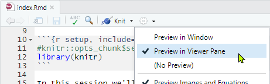

Sometimes you may see a *Preview Notebook* button instead of a *Knit* button. *Preview Notebook* shows you a rendered HTML copy of the contents of the editor but unlike *Knit*, *Preview Notebook* **does not** run any R code. Instead it reuses the output from when the code was last executed.

**Exercise 2**

1. Knit to HTML the notebook `my-notebook.Rmd` that you created in Exercise 1.
2. Observe the correspondence between the R Markdown and the resultant document.
3. Make some changes to the `.Rmd` file and re-knit the document.

TIP: Use the keyboard shortcut *Ctrl + Shift + K* to save and knit the notebook in one action.

# Structure of an `.Rmd` file

An R Markdown `.Rmd` file has three components:

1. Formatted text
2. Code chunks
3. YAML header

## Formatted Text

Text in `.Rmd` files are written in Pandoc’s Markdown[^4] whose syntax is designed to be human-readable and suggestive of its resultant HTML rendering. The text to be styled is usually pre- and suffixed by a special character. Below are the most common styles you’ll be using in R Notebooks.

### Inline text styles

*Italic* styling is done with single asterisks or underscores: `*italic*` or `_italic_`

**Bold** styling is done with double asterisks or underscores: `**bold**` or `__bold__`

*Bold & italic* styling is done with triple asterisks or underscores: `***bold & italic***` or `___bold & italic___`

`Inline code` styling is done with single back-ticks: `` `plot(iris)` ``

S<sup>uperscripting</sup> is done with carets: `S^uperscripting^`

S<sub>ubscripting</sub> is done with tildes: `S~ubscripting~`

Strikethrough is done with double tildes: `~~Strikethrough~~`

### $\LaTeX$ equations

Surrounding an expression with dollar symbols `$` will make R Markdown it as in-line $\LaTeX$ formatting.

`$\sum_{n=1}^{\infty} 2^{-n} = 1$` produces $\sum_{n=1}^{\infty} 2^{-n} = 1$.

Using double dollar symbols `$$` will centre the equation on its own line.

`$$\sum_{n=1}^{\infty} 2^{-n} = 1$$` produces

$$\sum_{n=1}^{\infty} 2^{-n} = 1$$

### Headings

Headings are specified using hash `#` prefixes.

`# Level 1 heading`

`## Level 2 heading`

`### Level 3 heading`

### Unordered Lists

Items of an unordered list are prefixed with an asterisk `*` (or hyphen `-` or plus `+`):

```
* Item 1

* Item 2
    * Item 2a
    * Item 2b
```

Inserting extra carriage returns spaces out the bullet points and tab stops nests bullet points.

- Item 1
- Item 2
  - Item 2a
  - Item 2b

### Ordered Lists

Ordered lists are prefixed with numbers or letters.

```
1. First ordered list item
2. Second ordered list item
    a. First nested ordered list item

    a. Second nested ordered list item

1. Third ordered list item
```

Notice that the numbering is incremented automatically in the output even if typed out of order.

1. First ordered list item
2. Second ordered list item
   1. First nested ordered list item
   2. Second nested ordered list item
3. Third ordered list item

### Links

Clickable URLs are inserted by enclosing the URL in greater-than `<` and less-than `>` symbols.

`<http://example.com>` for http://example.com

Custom anchor text is enclosed in square parentheses `[]` followed by the URL in round parentheses `()`.

`[hypertext link](http://example.com)` for [hypertext link](http://example.com)

### Images

Images are inserted by providing a file path to the image, either a link to a locally stored file or a URL to an image hosted online. Notice the leading exclamation mark `!` and caption in square parentheses `[]`. Leave the square parentheses empty for no caption.

`![Optional caption: Curtin University logo](https://global.curtin.edu.au/responsive-assets/img/logo-curtin-university.png)`

Optional caption: Curtin University logo

### Tables

You can manually create a text table by using hyphens `-` and pipes `|` to insert horizontal grid-lines and delineate columns, respectively. Rows are ended with a carriage return. It is a bit tricky though!

```
First Header  | Second Header | Third Header
------------- | ------------- | ------------
Cell content  | Cell content  | Cell content
Cell content  | Cell content  | Cell content
```

produces

| First Header | Second Header | Third Header |
| --- | --- | --- |
| Cell content | Cell content | Cell content |
| Cell content | Cell content | Cell content |

If the output of a code chunk is a table of values, R Markdown will render a table accordingly.

```r
head(iris)
```

[output not shown]

To get nicer looking tables we can use the `kable()` function from the `knitr` package.

```r
kable(head(iris))
```

[output not shown]

### Block quotations

```
> First level of quoting
>
> > Nested block quote
>
> Back to the first level
```

produces

> First level of quoting

> > Nested block quote

> Back to the first level

### Horizontal rule

Horizontal rules are inserted using three or more consecutive asterisks `*` (or hyphens `-`).

`---` produces

**Exercise 3**

1. Put a horizontal rule underneath the content in your R notebook from Exercise 2 (`my-notebook.Rmd`).
2. Below the rule insert a heading along the lines of “Table of Contents”
3. Under the heading, use an ordered list with nesting to create the outline of a typical scientific report, e.g., Introduction, Data Description, Methodology, etc.
4. Format some of the items in your table of contents using the styles mentioned above.
5. Add to your notebook (anywhere) a hypertext link to the ResBaz Perth 2019 homepage.
6. (Optional) Using $\LaTeX$ add (somewhere) to your notebook the equation for Pythagoras’ theorem or Euler’s identity.

## Code Chunks

Code is inserted into R Notebooks as ‘code chunks’.These chunks are then executed and their results inserted directly into the finished document. Embedding code alongside prose annotations of your methods and results speaks of the reproducible research paradigm.

Code chunks are enclosed by three back-ticks `` ``` `` followed by curly parentheses `{}` containing various parameters for the chunk.

````
```{r Structure of iris dataset}
str(iris)
```
````

The first parameter `r` indicates that the chunk contains R code. `knitr` provides support for many other languages such as Bash, Perl, SQL, Python, and Julia.

After the `r` is an optional name for this chunk. This helps with finding the chunk in the code navigator found in the bottom left of the editor pane.

The knitted notebook will therefore include both the code and its output in the finished file.

```r
str(iris)
```

```
'data.frame':   150 obs. of  5 variables:
 $ Sepal.Length: num  5.1 4.9 4.7 4.6 5 5.4 4.6 5 4.4 4.9 ...
 $ Sepal.Width : num  3.5 3 3.2 3.1 3.6 3.9 3.4 3.4 2.9 3.1 ...
 $ Petal.Length: num  1.4 1.4 1.3 1.5 1.4 1.7 1.4 1.5 1.4 1.5 ...
 $ Petal.Width : num  0.2 0.2 0.2 0.2 0.2 0.4 0.3 0.2 0.2 0.1 ...
 $ Species     : Factor w/ 3 levels "setosa","versicolor",..: 1 1 1 1 1 1 1 1 1 1 ...
```

**Exercise 4**

1. Add a new R chunk by clicking in your notebook where you want to insert the chunk and clicking the *Insert* button on the toolbar. Alternatively (and preferably) use the *Ctrl + Alt + I* keyboard shortcut.
2. Add the following code into the chunk `summary(iris)`.
3. Run the chunk by clicking the *Run Current Chunk* button within the chunk or by placing your cursor inside it and pressing *Ctrl + Shift + Enter*.

### Chunk options

Inside the curly parentheses `{}` that precede a code chunk we can specify options that affect how the results are knitted into the final document. We shall only cover a handful of options here and full documentation is found at https://yihui.name/knitr/options.

*1. Show the code and the output*

````
```{r}
colMeans(iris[,-5])
```
````

produces

```r
colMeans(iris[,-5])
```

[output not shown]

*2. Show the code but don’t execute it*

````
```{r, eval=FALSE}
colMeans(iris[,-5])
```
````

produces

```r
colMeans(iris[,-5])
```

*3. Show the output but don’t show the code*

````
```{r, echo=FALSE}
colMeans(iris[,-5])
```
````

*4. Execute the code but show anything*

````
```{r, include=FALSE}
colMeans(iris[,-5])
```
````

produces

*<blank>*

**Exercise 5**

1. Duplicate (copy/paste) the code chunk from Exercise 4 but specify each of the different options mentioned above. Observe the different output in the knitted document.

   Hint: instead of manually typing in the output options, RStudio provides a shortcut by clicking the cog icon found in the top right corner of the chunk, near to the *Run* button.

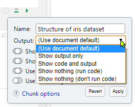

   Notice the [*Chunk options*](https://yihui.name/knitr/options/) link to online documentation of the available options.

### Inline R code

R code can be embedded inline with formatted text and be executed upon knitting.

`` The `iris` dataset has `r nrows(iris)` rows. `` produces

The `iris` dataset has 150 rows.

### Figure options

All the abovementioned code chunks only had numerical outputs. Here is an example of a chunk that produces a boxplot of the iris dataset, split by species.

````
```{r sepal width boxplot, echo=FALSE}
boxplot(Sepal.Width ~ Species, data = iris, col = hcl.colors(3))
```
````

produces

[figure not shown]

We can resize and align the plot using the `fig.height`, `fig.width=`, and `fig.align` chunk options.

[output not shown]

produces

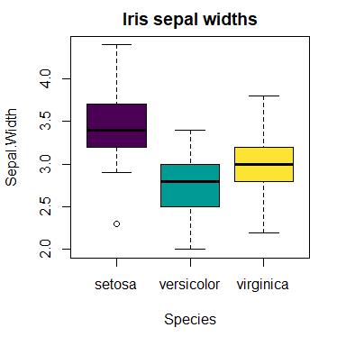

Other useful options include:

- `fig.asp`: set aspect ratio
- `fig.dim`: specify height and width as a tuple
- `fig.align`: align figure to left, right, or centre of page

## YAML Header

At the top of a `.Rmd` file is the YAML[^5] header enclosed by triple hyphens `---`. It specifies settings that affect the entire document, in particular the output type.

The default YAML header inserted by RStudio sets the R Markdown file to knit to an HTML notebook.

```
---
title: "R Notebook"
output: html_notebook
---
```

Other document output types include HTML document (distinct from HTML *notebook*), PDF, and Word. Not that PDF output requires $\LaTeX$ to be installed

```
---
title: "R Notebook"
output:
  html_document: default
  pdf_document: default
  word_document: default
---
```

Alternatively, you can produce a slideshow using `beamer`, `ioslides`, or `slidy` as the output parameter.

```
---
title: "R Presentation"
output:
  beamer_presentation: default
  ioslides_presentation: default
  slidy_presentation: default
---
```

### HTML document settings

For this lesson we shall focus upon knitting HTML documents for which there are many settings that we can set in the YAML header. Here is the YAML header for the `.Rmd` file that produced this HTML document.

```
---
title: "Introduction to R Markdown"
author: "Shih Ching Fu"
date: "ResBaz Perth 2019"
output:
  html_document:
    toc: true
    toc_depth: 2
    toc_float:
      collapsed: false
      smooth_scroll: true
    number_sections: true
    theme: united
    highlight: tango
    fig_width: 7
    fig_height: 6
    fig_caption: true
    code_folding: hide
    df_print: paged
bibliography: ref.bib
---
```

# References

Grolemund, Garrett, and Hadley Wickham. 2017. *R for Data Science*. O’Reilly Media.

RStudio. 2018. “R Markdown.” https://rmarkdown.rstudio.com/index.html.

Wright, Thomas, and Naupaka Zimmerman, eds. 2016. “Software Carpentry: R for Reproducible Scientific Analysis.” https://doi.org/10.5281/zenodo.57520.

Xie, Yihui, J.J. Allaire, and Garrett Grolemund. 2018. *R Markdown: The Definitive Guide*. CRC Press.

[^1]: RStudio, https://www.rstudio.com/
[^2]: knitr, http://yihui.name/knitr/
[^3]: pandoc, http://pandoc.org/
[^4]: Pandoc’s Markdown, https://pandoc.org/MANUAL.html#pandocs-markdown
[^5]: YAML stands for Yet Another Markup Language